# 餐廳訪客數預測及分析

109072114 金品妤

# 1 研究動機

我之所以選擇分析餐廳訪客數的主題作為期末報告是因為我希望在未來能夠從事商業分析師的工作，目前正朝著數據分析與行銷管理的方向去修習課程，藉此讓我能夠對市場以及業界有敏銳的洞察力。預測餐廳訪客數一直以來都是一項具有重要意義的研究，對於餐廳經營者和業界來說都具有巨大的價值。這項研究的目的在於提供餐廳經營者們一個有效的工具，能夠預測未來的訪客數量，以便他們能夠更好地規劃和管理自己的業務。

# 2 前言摘要

我的期末報告的主題是從Kaggle找感到有興趣的比賽來做，最終選了餐廳訪客數分析這個題目。經營一家生意興隆的餐廳經常會出現可能導致虧損，甚至是倒閉等意想不到的麻煩。而常見的難處是餐廳需要知道每天會有多少顧客才能有效地購買食材和安排員工，想要做出這個預測便需要考慮許多不可預測的因素，例如假期、當地競爭密集度和天氣等等。希望藉由這次報告來預測餐廳未來的訪客總數，幫助餐廳提高效率，並讓他們專注於為顧客創造愉快的用餐體驗。

# 3 資料蒐集

1. 來源：數據以 8 個文件組成，這些文件主要來自兩個專門用來蒐集用戶信息的日本網站： Hot Pepper Gourmet （hpg）、AirREGI / Restaurant Board（air）
- **air_visit_data.csv**: *air* 餐廳的歷史拜訪數據，為主要訓練集
- **air_reserve.csv** / **hpg_reserve.csv**: 來自 *air* / *hpg* 系統的預訂數據
- **air_store_info.csv** / **hpg_store_info.csv**: 有關 *air* / *hpg* 餐廳的詳細信息，包括餐廳類型和地理位置
- **store_id_relation.csv**: 這是連接*air* / *hpg* id 的關係文件，只有 150 組，不到所有商店的 20%
- **date_info.csv**: 主要用來註記日本的假期
- **sample_submission.csv**: 用來做為測試集
2. 時間：訓練數據基於 2016 年至 2017 年 4 月大多數的時間範圍，而測試集包括2017 年 4 月的最後一周加上 5 月。此外，由於測試集中有幾天（假期週）餐廳關閉且並沒有訪客，而這些在評分中被忽略，因此訓練集中我們省略了餐廳關閉的日子。

## 3.1 資料匯入讀取

### 3.1.1 套件

```r
# general visualisation
library('ggplot2') # visualisation
library('scales') # visualisation
library('grid') # visualisation
library('gridExtra') # visualisation
library('RColorBrewer') # visualisation
library('corrplot') # visualisation

# general data manipulation
library('dplyr') # data manipulation
library('readr') # input/output
library('data.table') # data manipulation

library('tibble') # data wrangling
library('tidyr') # data wrangling
library('stringr') # string manipulation
library('forcats') # factor manipulation

# specific visualisation
library('ggrepel') # visualisation
library('ggridges') # visualisation
library('ggExtra') # visualisation
library('ggforce') # visualisation
library('viridis') # visualisation
library('kableExtra')

# specific data manipulation
library('lazyeval') # data wrangling
library('broom') # data wrangling
library('purrr') # string manipulation

# Date plus forecast
library('lubridate') # date and time
library('timeDate') # date and time
library('tseries') # time series analysis
library('forecast') # time series analysis
library('prophet') # time series analysis
options(repos = c(CRAN = "https://cloud.r-project.org"))
#library('timetk') # time series analysis

# Maps / geospatial
library('geosphere') # geospatial locations
library('leaflet') # maps
library('leaflet.extras') # maps
library('maps') # maps
```

### 3.1.2 函數

使用 R Cookbooks 提供的 multiplot function 來創建 multiple plot。

```r
# Define multiple plot function

multiplot <- function(..., plotlist=NULL, file, cols=1, layout=NULL) {

    plots <- c(list(...), plotlist)

  numPlots = length(plots)

  if (is.null(layout)) {
    layout <- matrix(seq(1, cols * ceiling(numPlots/cols)),
                    ncol = cols, nrow = ceiling(numPlots/cols))
  }

 if (numPlots==1) {
    print(plots[[1]])

  } else {
      grid.newpage()
    pushViewport(viewport(layout = grid.layout(nrow(layout), ncol(layout))))

      for (i in 1:numPlots) {
      matchidx <- as.data.frame(which(layout == i, arr.ind = TRUE))

      print(plots[[i]], vp = viewport(layout.pos.row = matchidx$row,
                                      layout.pos.col = matchidx$col))
    }
  }
}
```

```r
# function to extract binomial confidence levels
get_binCI <- function(x,n) as.list(setNames(binom.test(x,n)$conf.int, c("lwr", "upr")))
```

### 3.1.3 數據集

```r
library(readr)
air_visits <- read_csv("C:\\Users\\USER\\Desktop\\金融大數據\\recruit-restaurant-visitor-forecasting\\air_visit_data.csv.zip", col_types = cols())
air_reserve <- read_csv("C:\\Users\\USER\\Desktop\\金融大數據\\recruit-restaurant-visitor-forecasting\\air_reserve.csv.zip", col_types = cols())
hpg_reserve <- read_csv("C:\\Users\\USER\\Desktop\\金融大數據\\recruit-restaurant-visitor-forecasting\\hpg_reserve.csv.zip", col_types = cols())
air_store <- read_csv("C:\\Users\\USER\\Desktop\\金融大數據\\recruit-restaurant-visitor-forecasting\\air_store.csv.zip", col_types = cols())
hpg_store <- read_csv("C:\\Users\\USER\\Desktop\\金融大數據\\recruit-restaurant-visitor-forecasting\\hpg_store.csv.zip", col_types = cols())
holidays <- read_csv("C:\\Users\\USER\\Desktop\\金融大數據\\recruit-restaurant-visitor-forecasting\\holidays.csv.zip", col_types = cols())
store_ids <- read_csv("C:\\Users\\USER\\Desktop\\金融大數據\\recruit-restaurant-visitor-forecasting\\store_ids.csv.zip", col_types = cols())
test <- read_csv("C:\\Users\\USER\\Desktop\\金融大數據\\recruit-restaurant-visitor-forecasting\\test.csv.zip", col_types = cols())
```

## 3.2 資料前處理（data wrangling）

透過觀察有無缺失值或離群值，進行清理數據，例如處理遺失值(missing value) 或離群值(outlier) ，或組合來自多個來源的數據。 剛好這次數據中都沒有缺失值，超棒的！不然處理起來一定會很辛苦。

## 3.3 特徵格式化

更改日期與時間特徵的格式，並將一些特徵重新格式化以利用於分析。

```r
air_visits <- air_visits %>%
  mutate(visit_date = ymd(visit_date))

air_reserve <- air_reserve %>%
  mutate(visit_datetime = ymd_hms(visit_datetime),
         reserve_datetime = ymd_hms(reserve_datetime))

hpg_reserve <- hpg_reserve %>%
  mutate(visit_datetime = ymd_hms(visit_datetime),
         reserve_datetime = ymd_hms(reserve_datetime))

air_store <- air_store %>%
  mutate(air_genre_name = as.factor(air_genre_name),
         air_area_name = as.factor(air_area_name))

hpg_store <- hpg_store %>%
  mutate(hpg_genre_name = as.factor(hpg_genre_name),
         hpg_area_name = as.factor(hpg_area_name))

holidays <- holidays %>%
  mutate(holiday_flg = as.logical(holiday_flg),
         date = ymd(calendar_date),
         calendar_date = as.character(calendar_date))
```

# 4 EDA(Exploratory Data Analysis)

首先觀察各個 data 中特徵的分佈，接著再將它們組合起來進行更詳細的分析。

## 4.1 個別特徵視覺化

從初步視覺化作為建構分析的基礎。

### 4.1.1 Air Visits

先從 *air* 餐廳的訪客次數開始。 下圖是整個 *training* 時間範圍內 *每天* 的訪客總數以及 *一周中每天* 和 *一年中每月* 的訪客中位數。

圖表分析：

- 在時間序列中段遽增可能是因為新添加到data中的新餐館導致，此外，可以觀察到可能對應於每週週期的周期性模式。
- 每家餐廳每日光顧的客人數量主要落在 20 人左右（紅線），極少數情況超過 100。
- 週五和周末平均訪客最多；而週一和周二最少。
- 在這一年中也有一定的變化。 十二月最受歡迎，而3 月至 5 月也頗高。

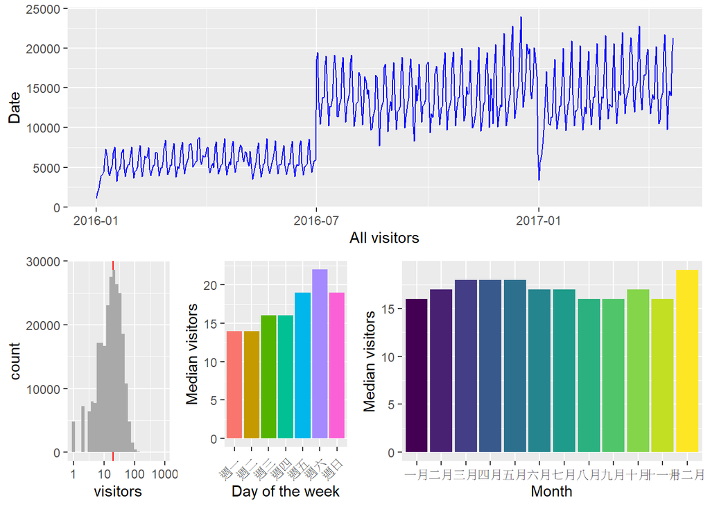

Fig. 1

```r
p1 <- air_visits %>%
  group_by(visit_date) %>%
  summarise(all_visitors = sum(visitors)) %>%
  ggplot(aes(visit_date,all_visitors)) +
  geom_line(col = "blue") +
  labs(x = "All visitors", y = "Date")

p2 <- air_visits %>%
  ggplot(aes(visitors)) +
  geom_vline(xintercept = 20, color = "red") +
  geom_histogram(fill = "dark gray", bins = 30) +
  scale_x_log10()

p3 <- air_visits %>%
  mutate(wday = lubridate::wday(visit_date, label = TRUE, week_start = 1)) %>%
  group_by(wday) %>%
  summarise(visits = median(visitors)) %>%
  ggplot(aes(wday, visits, fill = wday)) +
  geom_col() +
  theme(legend.position = "none", axis.text.x  = element_text(angle=45, hjust=1, vjust=0.9)) +
  labs(x = "Day of the week", y = "Median visitors") +
  scale_fill_hue()

p4 <- air_visits %>%
  mutate(month = lubridate::month(visit_date, label = TRUE)) %>%
  group_by(month) %>%
  summarise(visits = median(visitors)) %>%
  ggplot(aes(month, visits, fill = month)) +
  geom_col() +
  theme(legend.position = "none") +
  labs(x = "Month", y = "Median visitors")

layout <- matrix(c(1,1,1,1,2,3,4,4),2,4,byrow=TRUE)
multiplot(p1, p2, p3, p4, layout=layout)
```

因為要預測的是2017 年 4 月的最後一周加上 2017 年 5 月，所以再特別把 2016 年這個時間範圍拉出來看。 黑線是日期，藍線對應於相應灰色信賴區域的 smoothing fit 。

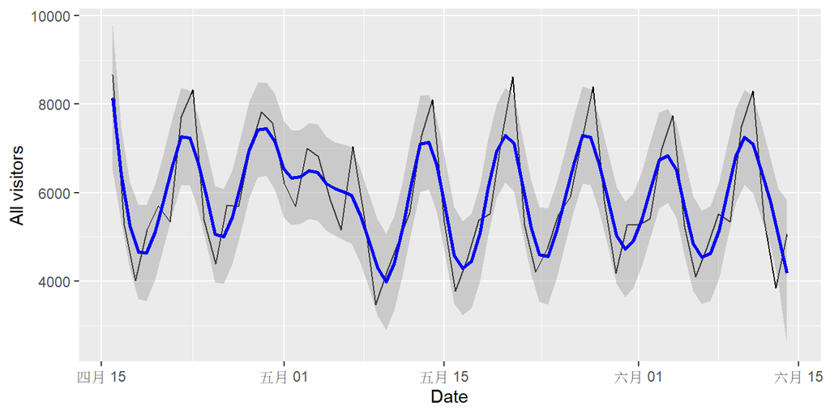

Fig. 2

```r
air_visits %>%
  filter(visit_date > ymd("2016-04-15") & visit_date < ymd("2016-06-15")) %>%
  group_by(visit_date) %>%
  summarise(all_visitors = sum(visitors)) %>%
  ggplot(aes(visit_date,all_visitors)) +
  geom_line() +
  geom_smooth(method = "loess", color = "blue", span = 1/7) +
  labs(y = "All visitors", x = "Date")
```

### 4.1.2 Air Reserves

觀察 *air* 預訂數據與實際訪客數量的比較。

圖表分析:

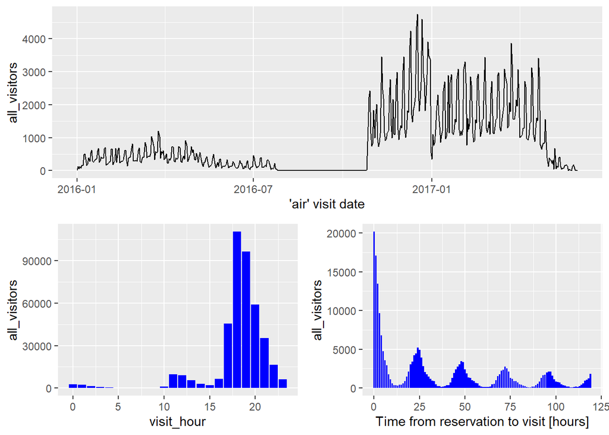

Fig. 3

```r
foo <- air_reserve %>%
  mutate(reserve_date = date(reserve_datetime),
         reserve_hour = hour(reserve_datetime),
         reserve_wday = lubridate::wday(reserve_datetime, label = TRUE, week_start = 1),
         visit_date = date(visit_datetime),
         visit_hour = hour(visit_datetime),
         visit_wday = lubridate::wday(visit_datetime, label = TRUE, week_start = 1),
         diff_hour = time_length(visit_datetime - reserve_datetime, unit = "hour"),
         diff_day = time_length(visit_datetime - reserve_datetime, unit = "day")
         )

p1 <- foo %>%
  group_by(visit_date) %>%
  summarise(all_visitors = sum(reserve_visitors)) %>%
  ggplot(aes(visit_date, all_visitors)) +
  geom_line() +
  labs(x = "'air' visit date")

p2 <- foo %>%
  group_by(visit_hour) %>%
  summarise(all_visitors = sum(reserve_visitors)) %>%
  ggplot(aes(visit_hour, all_visitors)) +
  geom_col(fill = "blue")

p3 <- foo %>%
  filter(diff_hour < 24*5) %>%
  group_by(diff_hour) %>%
  summarise(all_visitors = sum(reserve_visitors)) %>%
  ggplot(aes(diff_hour, all_visitors)) +
  geom_col(fill = "blue") +
  labs(x = "Time from reservation to visit [hours]")

layout <- matrix(c(1,1,2,3),2,2,byrow=TRUE)
multiplot(p1, p2, p3, layout=layout)
```

### 4.1.3 HPG Reserves

和前面方法一樣，這邊換作是觀察 *hpg* 預訂數據與實際訪客數量的比較。

圖表分析:

- 與上面數據一樣，2016 年 12 月出現明顯飆升，還可以看到預約量隨著接近時間範圍的末端下降。
- 同樣大多數預訂都是晚餐
- 特別的是，訪問前最後幾個小時的流量並不比 24 或 48 小時前更多，與前者數據差別很大。

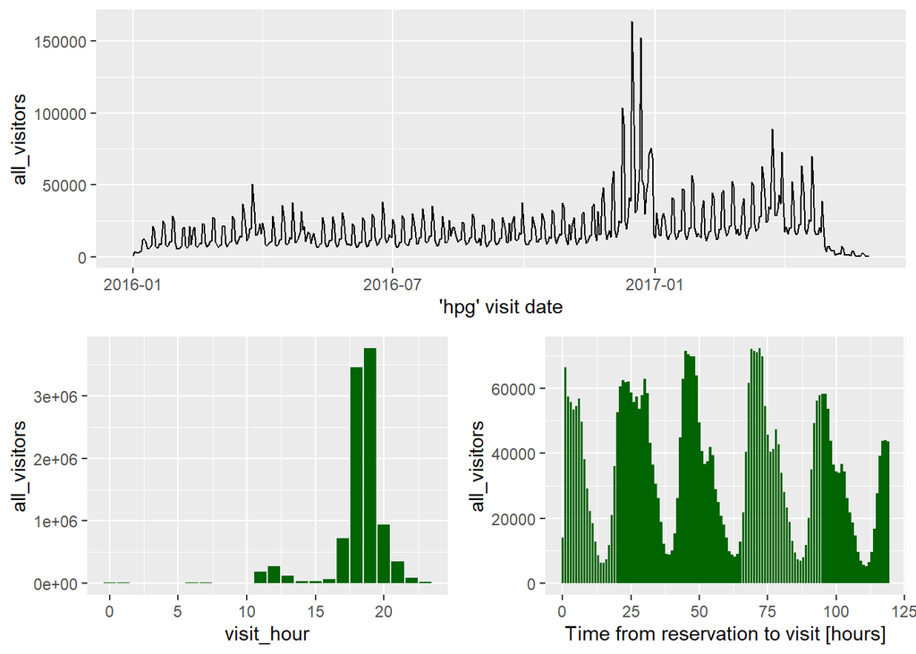

Fig. 4

```r
foo <- hpg_reserve %>%
  mutate(reserve_date = date(reserve_datetime),
         reserve_hour = hour(reserve_datetime),
         visit_date = date(visit_datetime),
         visit_hour = hour(visit_datetime),
         diff_hour = time_length(visit_datetime - reserve_datetime, unit = "hour"),
         diff_day = time_length(visit_datetime - reserve_datetime, unit = "day")
         )

p1 <- foo %>%
  group_by(visit_date) %>%
  summarise(all_visitors = sum(reserve_visitors)) %>%
  ggplot(aes(visit_date, all_visitors)) +
  geom_line() +
  labs(x = "'hpg' visit date")

p2 <- foo %>%
  group_by(visit_hour) %>%
  summarise(all_visitors = sum(reserve_visitors)) %>%
  ggplot(aes(visit_hour, all_visitors)) +
  geom_col(fill = "dark green")

p3 <- foo %>%
  filter(diff_hour < 24*5) %>%
  group_by(diff_hour) %>%
  summarise(all_visitors = sum(reserve_visitors)) %>%
  ggplot(aes(diff_hour, all_visitors)) +
  geom_col(fill = "dark green") +
  labs(x = "Time from reservation to visit [hours]")

layout <- matrix(c(1,1,2,3),2,2,byrow=TRUE)
multiplot(p1, p2, p3, layout=layout)
```

### 4.1.4 Air Store

利用可縮放地圖查看所有 *air* 餐廳的地理位置。 點一下可以把它們分解成更小的聚點，並最終分解為按照類型標記的各個餐廳。

```r
leaflet(air_store) %>%
  addTiles() %>%
  addProviderTiles("CartoDB.Positron") %>%
  addMarkers(~longitude, ~latitude,
             popup = ~air_store_id, label = ~air_genre_name,
             clusterOptions = markerClusterOptions())
```

[interactive chart not shown]

Fig. 5

接著將不同類型的餐廳數量與最多 *air* 餐廳的區域做成圖表

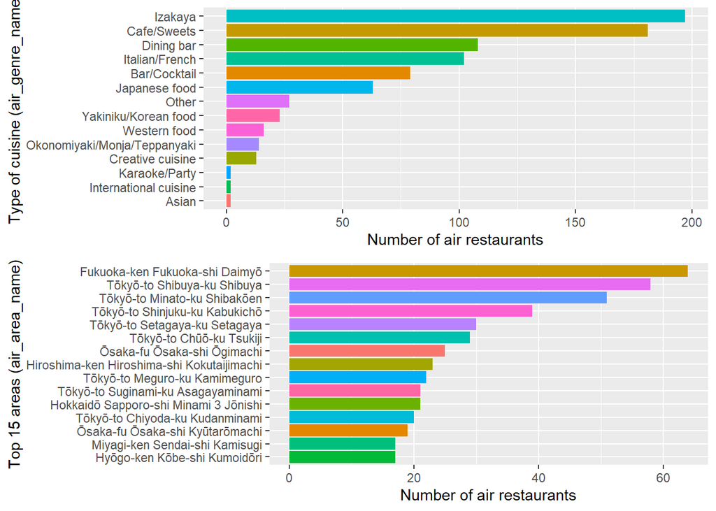

Fig. 6

```r
p1 <- air_store %>%
  group_by(air_genre_name) %>%
  count() %>%
  ggplot(aes(reorder(air_genre_name, n, FUN = min), n, fill = air_genre_name)) +
  geom_col() +
  coord_flip() +
  theme(legend.position = "none") +
  labs(x = "Type of cuisine (air_genre_name)", y = "Number of air restaurants")

p2 <- air_store %>%
  group_by(air_area_name) %>%
  count() %>%
  ungroup() %>%
  top_n(15,n) %>%
  ggplot(aes(reorder(air_area_name, n, FUN = min) ,n, fill = air_area_name)) +
  geom_col() +
  theme(legend.position = "none") +
  coord_flip() +
  labs(x = "Top 15 areas (air_area_name)", y = "Number of air restaurants")

layout <- matrix(c(1,2),2,1,byrow=TRUE)
multiplot(p1, p2, layout=layout)
```

### 4.1.5 HPG Store

```r
leaflet(hpg_store) %>%
  addTiles() %>%
  addProviderTiles("CartoDB.Positron") %>%
  addMarkers(~longitude, ~latitude,
             popup = ~hpg_store_id, label = ~hpg_genre_name,
              clusterOptions = markerClusterOptions())
```

[output not shown]

將不同類型的餐廳數量與最多 *HPG* 餐廳的區域做成圖表

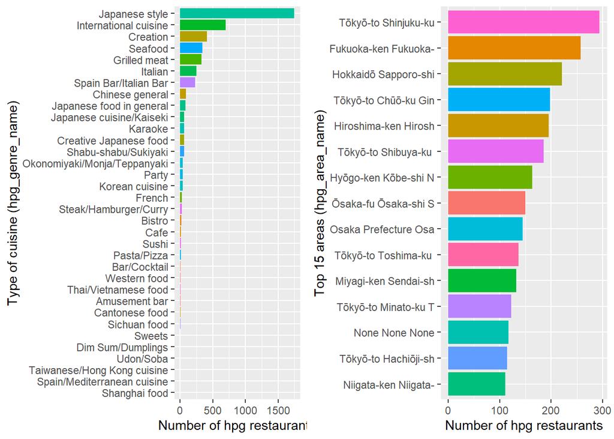

Fig. 8

```r
p1 <- hpg_store %>%
  group_by(hpg_genre_name) %>%
  count() %>%
  ggplot(aes(reorder(hpg_genre_name, n, FUN = min), n, fill = hpg_genre_name)) +
  geom_col() +
  coord_flip() +
  theme(legend.position = "none") +
  labs(x = "Type of cuisine (hpg_genre_name)", y = "Number of hpg restaurants")

p2 <- hpg_store %>%
  mutate(area = str_sub(hpg_area_name, 1, 20)) %>%
  group_by(area) %>%
  count() %>%
  ungroup() %>%
  top_n(15,n) %>%
  ggplot(aes(reorder(area, n, FUN = min) ,n, fill = area)) +
  geom_col() +
  theme(legend.position = "none") +
  coord_flip() +
  labs(x = "Top 15 areas (hpg_area_name)", y = "Number of hpg restaurants")

layout <- matrix(c(1,2),1,2,byrow=TRUE)
multiplot(p1, p2, layout=layout)
```

### 4.1.6 Holidays

繪製出在 2016 年和 2017 年預測時間範圍內的假期分佈情況以便查看

圖表分析：

- 2016 年四到六月的假期 2017 年一樣
- 數據中假期大約佔 7%

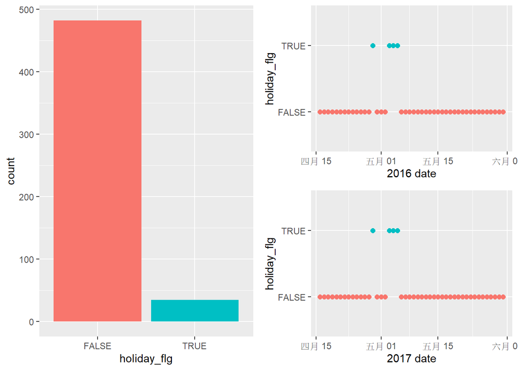

Fig. 9

```r
foo <- holidays %>%
  mutate(wday = base::format(date, "%u"))

p1 <- foo %>%
  ggplot(aes(holiday_flg, fill = holiday_flg)) +
  geom_bar() +
  theme(legend.position = "none")

p2 <- foo %>%
  filter(date > ymd("2016-04-15") & date < ymd("2016-06-01")) %>%
  ggplot(aes(date, holiday_flg, color = holiday_flg)) +
  geom_point(size = 2) +
  theme(legend.position = "none") +
  labs(x = "2016 date")

p3 <- foo %>%
  filter(date > ymd("2017-04-15") & date < ymd("2017-06-01")) %>%
  ggplot(aes(date, holiday_flg, color = holiday_flg)) +
  geom_point(size = 2) +
  theme(legend.position = "none") +
  labs(x = "2017 date")

layout <- matrix(c(1, 1, 2, 3), 2, 2, byrow = FALSE)
multiplot(p1, p2, p3, layout = layout)
```

### 4.1.7 Test data set

下圖視覺化了訓練集與測試集的時間範圍:

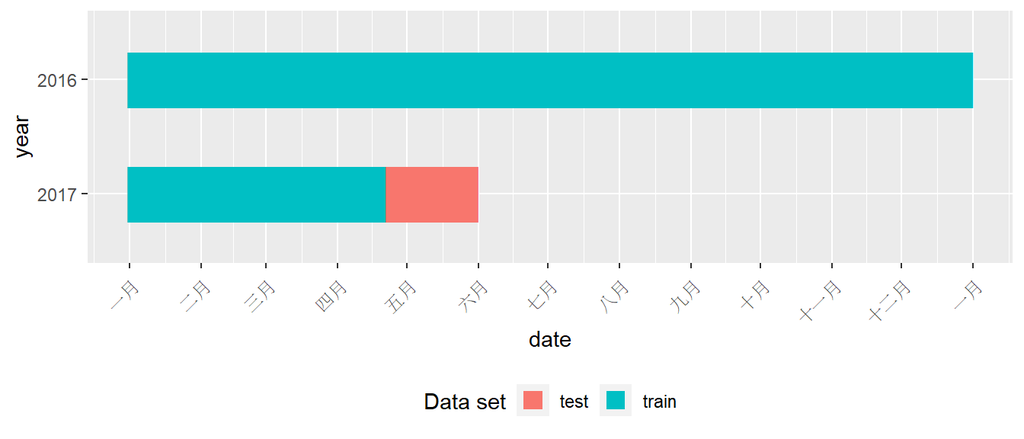

Fig. 10

```r
foo <- air_visits %>%
  rename(date = visit_date) %>%
  distinct(date) %>%
  mutate(dset = "train")

bar <- test %>%
  separate(id, c("foo", "bar", "date"), sep = "_") %>%
  mutate(date = ymd(date)) %>%
  distinct(date) %>%
  mutate(dset = "test")

foo <- foo %>%
  bind_rows(bar) %>%
  mutate(year = year(date))
year(foo$date) <- 2017

foo %>%
  filter(!is.na(date)) %>%
  mutate(year = fct_relevel(as.factor(year), c("2017","2016"))) %>%
  ggplot(aes(date, year, color = dset)) +
  geom_point(shape = "|", size = 10) +
  scale_x_date(date_labels = "%B", date_breaks = "1 month") +
  #scale_y_reverse() +
  theme(legend.position = "bottom", axis.text.x  = element_text(angle=45, hjust=1, vjust=0.9)) +
  labs(color = "Data set") +
  guides(color = guide_legend(override.aes = list(size = 4, pch = 15)))
```

## 4.2 特徵關係(Feature relations)

### 4.2.1 Visitors / genre

- 每日每種類型的平均值在 10 到 100 名訪客之間且在每個類別中，長期趨勢相當穩定。
- 在所有曲線中都有規律每週變化，所以可以更了解每週每日和類型的平均訪問者數量。

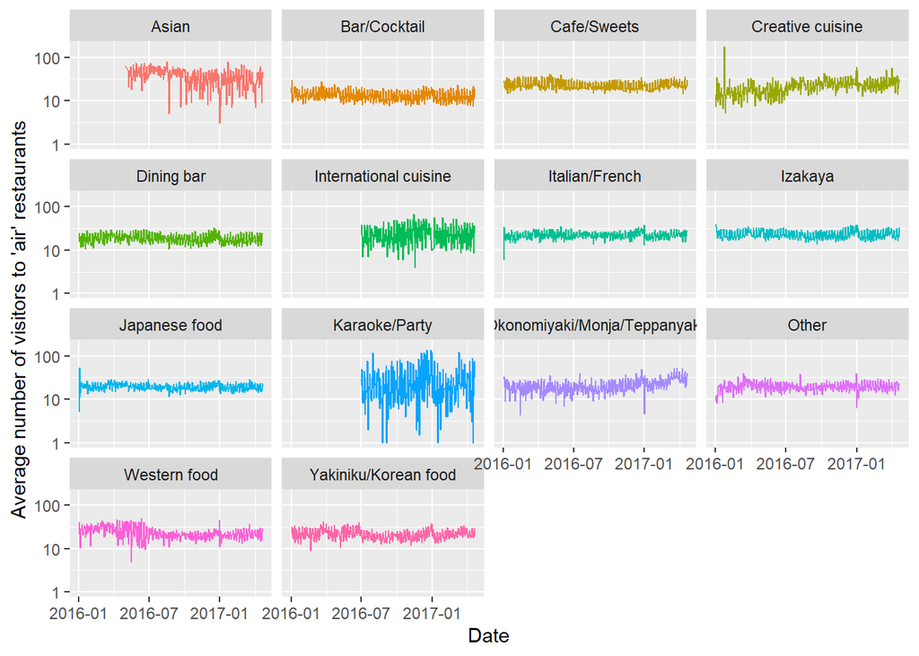

Fig. 11

```r
foo <- air_visits %>%
  left_join(air_store, by = "air_store_id")

foo %>%
  group_by(visit_date, air_genre_name) %>%
  summarise(mean_visitors = mean(visitors)) %>%
  ungroup() %>%
  ggplot(aes(visit_date, mean_visitors, color = air_genre_name)) +
  geom_line() +
  labs(y = "Average number of visitors to 'air' restaurants", x = "Date") +
  theme(legend.position = "none") +
  scale_y_log10() +
  facet_wrap(~ air_genre_name)
```

### 4.2.2 Visitors / holidays

比較有假期和沒有假期記號的天數的統計數據來研究假期對訪客數量的影響：

- 從大致上來看，假期對平均訪客人數沒有什麼影響。
- 但從右圖來看雖然週末假期對遊客數量的影響很小，甚至略有減少，但工作日的影響更為明顯； 特別是周一和周二。

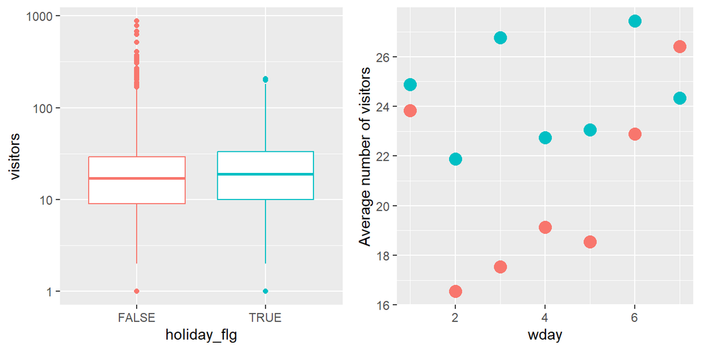

Fig. 13

```r
foo <- air_visits %>%
  mutate(calendar_date = as.character(visit_date)) %>%
  left_join(holidays, by = "calendar_date")

p1 <- foo %>%
  ggplot(aes(holiday_flg, visitors, color = holiday_flg)) +
  geom_boxplot() +
  scale_y_log10() +
  theme(legend.position = "none")

p2 <- foo %>%
  mutate(wday = wday(date)) %>%
  group_by(wday, holiday_flg) %>%
  summarise(mean_visitors = mean(visitors)) %>%
  ggplot(aes(wday, mean_visitors, color = holiday_flg)) +
  geom_point(size = 4) +
  theme(legend.position = "none") +
  labs(y = "Average number of visitors")

layout <- matrix(c(1,2),1,2,byrow=TRUE)
multiplot(p1, p2, layout=layout)
```

### 4.2.3 Visitors / restaurants area

用計數圖觀察每個區域特定類型的餐廳數量及研究其對遊客數量的影響。

下圖顯示了 *air* data 哪些類型存在於哪些區域:

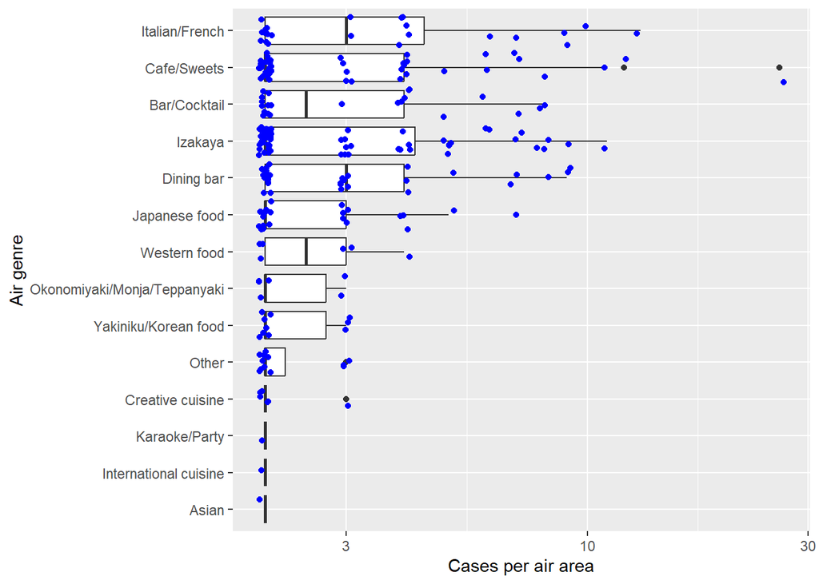

Fig. 16

```r
air_store %>%
  group_by(air_genre_name, air_area_name) %>%
  count() %>%
  ggplot(aes(reorder(air_genre_name, n, FUN = mean), n)) +
  geom_boxplot() +
  geom_jitter(color = "blue") +
  scale_y_log10() +
  coord_flip() +
  labs(x = "Air genre", y = "Cases per air area")
```

分析結果:

- 只有少數種類的平均每個區域超過 2 家餐廳。 例如意大利/法式餐廳或酒吧/雞尾酒場所
- 大多數種類分佈集中在每區 2 家，並向更高的數目分散。以咖啡館的數量最多，在一個地區出現了 26 次
- 最特別的事情是，這邊的最小值是 2，而並非 1。這代表沒有 *air* 餐廳是任何區域中唯一的種類的餐廳。

以下是來自 *hpg* 數據的分佈：

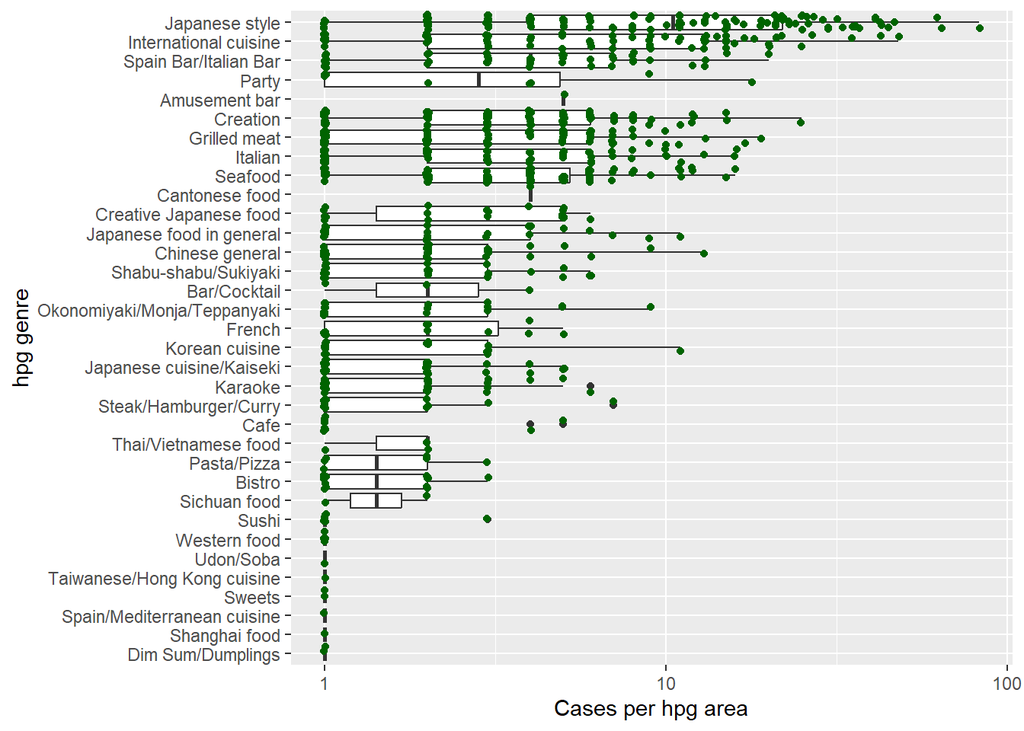

Fig. 17

```r
foobar <- hpg_store %>%
  group_by(hpg_genre_name, hpg_area_name) %>%
  count()

foobar %>%
  ggplot(aes(reorder(hpg_genre_name, n, FUN = mean), n)) +
  geom_boxplot() +
  geom_jitter(color = "dark green") +
  scale_y_log10() +
  coord_flip() +
  labs(x = "hpg genre", y = "Cases per hpg area")
```

分析結果:

- 每個區域至少有 1 個種類，而且由於總數較多，中位數也有更多種類。
- 最極端的種類是日式，每個地區的餐廳數量中位數略高於 10 家。

除此之外，可以利用每個區域種類數量的訊息，繼續量化 data 的聚集區或擁擠度，並將它們與訪客量相關聯。

這張圖顯示出了最後兩個圖中 *air* 和 *hpg* data 的總體分佈

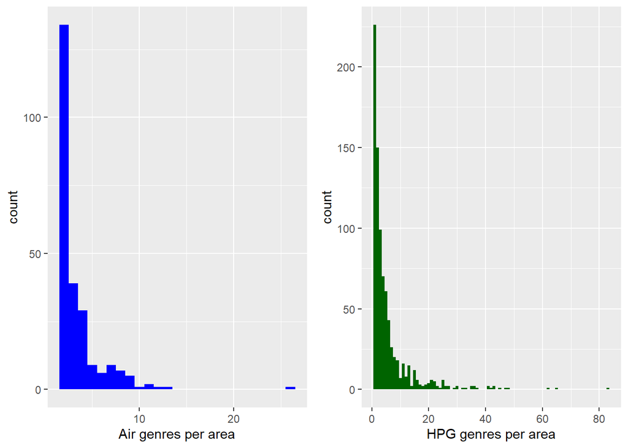

Fig. 18

```r
foo <- air_visits %>%
  left_join(air_store, by = "air_store_id")

bar <- air_store %>%
  group_by(air_genre_name, air_area_name) %>%
  count()

foobar <- hpg_store %>%
  group_by(hpg_genre_name, hpg_area_name) %>%
  count()

p1 <- bar %>%
  ggplot(aes(n)) +
  geom_histogram(fill = "blue", binwidth = 1) +
  labs(x = "Air genres per area")

p2 <- foobar %>%
  ggplot(aes(n)) +
  geom_histogram(fill = "dark green", binwidth = 1) +
  labs(x = "HPG genres per area")

layout <- matrix(c(1,2), 1, 2, byrow = TRUE)
multiplot(p1, p2, layout = layout)
```

上面兩張圖:

- 在 *air* 和 *hpg* 數據集中同一地區相同類型的數量皆迅速下降，大致呈指數下降。
- 分佈中 *air* 的第二個高峰值大概在 8 左右，*hpg* 約為 13 。

### 4.2.4 Visitors / reservations

先計算每家餐廳每天的預訂人數加總，然後將這些加入到 *air_visitors* data，而為了包含 *hpg* 的預訂資料， 需要使用 *store_ids* 數據將 *hpg_store_ids* 從 *hpg_reserve* 文件連接到相應的 *air_store_ids*：

```r
foo <- air_reserve %>%
  mutate(visit_date = date(visit_datetime)) %>%
  group_by(air_store_id,visit_date) %>%
  summarise(reserve_visitors_air = sum(reserve_visitors))

bar <- hpg_reserve %>%
  mutate(visit_date = date(visit_datetime)) %>%
  group_by(hpg_store_id,visit_date) %>%
  summarise(reserve_visitors_hpg = sum(reserve_visitors)) %>%
  inner_join(store_ids, by = "hpg_store_id")

all_reserve <- air_visits %>%
  inner_join(foo, by = c("air_store_id", "visit_date")) %>%
  inner_join(bar, by = c("air_store_id", "visit_date")) %>%
  mutate(reserve_visitors = reserve_visitors_air + reserve_visitors_hpg)
```

接著再根據 *air* 餐廳的實際訪客人數繪製總 *reserve_visitor* 數散點圖

灰線顯示 *reserve_visitors == visitors* ，而藍線則是線性擬合

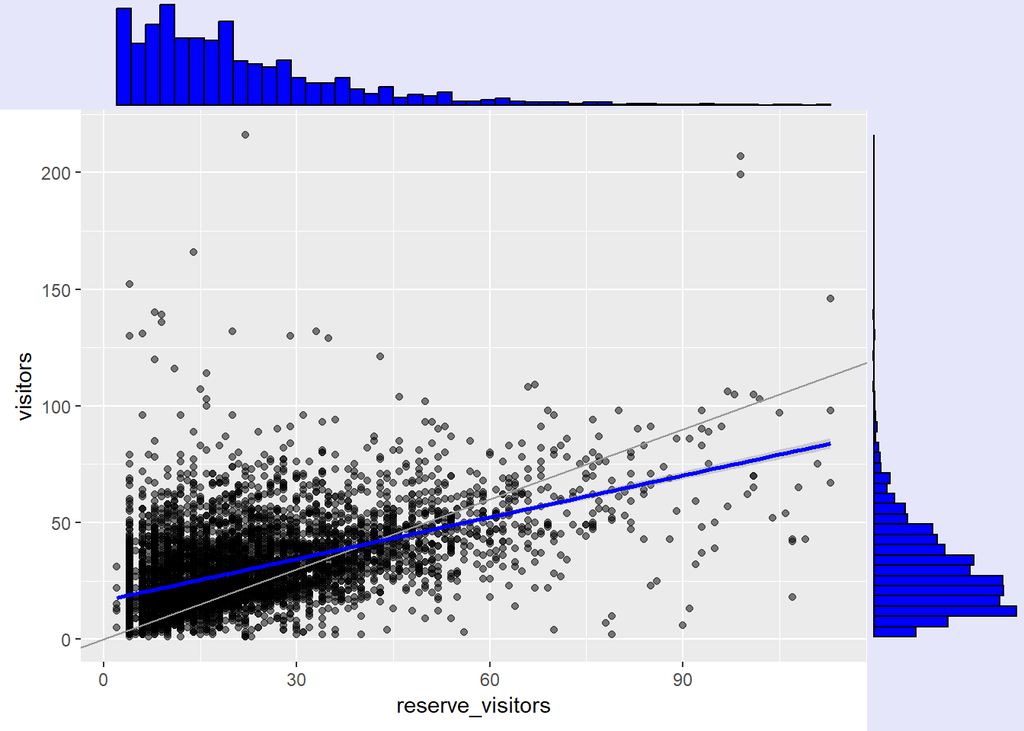

Fig. 19

```r
p <- all_reserve %>%
  filter(reserve_visitors < 120) %>%
  ggplot(aes(reserve_visitors, visitors)) +
  geom_point(color = "black", alpha = 0.5) +
  geom_abline(slope = 1, intercept = 0, color = "grey60") +
  geom_smooth(method = "lm", color = "blue")
ggMarginal(p, type="histogram", fill = "blue", bins=50)
```

最後使用重疊密度圖，簡潔探討一下假期對預訂數和訪客數之間差異的影響：

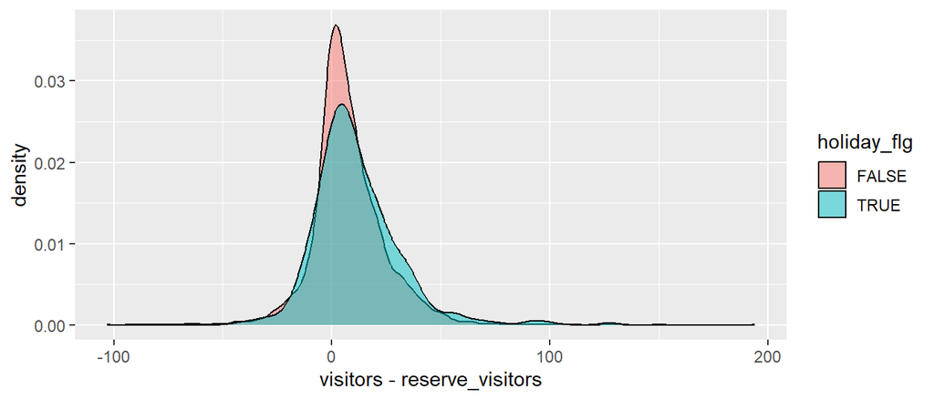

Fig. 21

```r
all_reserve %>%
  mutate(date = visit_date) %>%
  left_join(holidays, by = "date") %>%
  ggplot(aes(visitors - reserve_visitors, fill = holiday_flg)) +
  geom_density(alpha = 0.5)
```

訪客人數與假期預訂數相比更多一些，兩者峰值幾乎相同，但些許較大數字有明顯的差異。

# 5 時間序列參數(Time series parameters)

觀察訪客數量的時間序列:

採用不同的特性查看每個時間序列的 meta 參數，例如均值、標準差、斜率和斜率誤差， 而每個參數都是由 log1p 轉換後的數據計算來的

```r
foo <- air_visits %>%
  left_join(air_store, by = "air_store_id") %>%
  group_by(air_store_id, air_genre_name) %>%
  summarise(mean_log_visits = mean(log1p(visitors)),
            mean_log_visits = mean(log1p(visitors)),
            sd_log_visits = sd(log1p(visitors))) %>%
  ungroup()

params_ts1 <- function(rownr){
  bar <- air_visits %>%
    filter(air_store_id == foo$air_store_id[rownr])
  slope <- summary(lm(visitors ~ visit_date, data = bar))$coef[2]
  slope_err <- summary(lm(visitors ~ visit_date, data = bar))$coef[4]

  foobar <- tibble(
    air_store_id = foo$air_store_id[rownr],
    slope = slope,
    slope_err = slope_err
  )

  return(foobar)
}

params <- params_ts1(1)
for (i in seq(2,nrow(foo))){
  params <- bind_rows(params, params_ts1(i))
}

ts_params <- foo %>%
  left_join(params, by = "air_store_id")
```

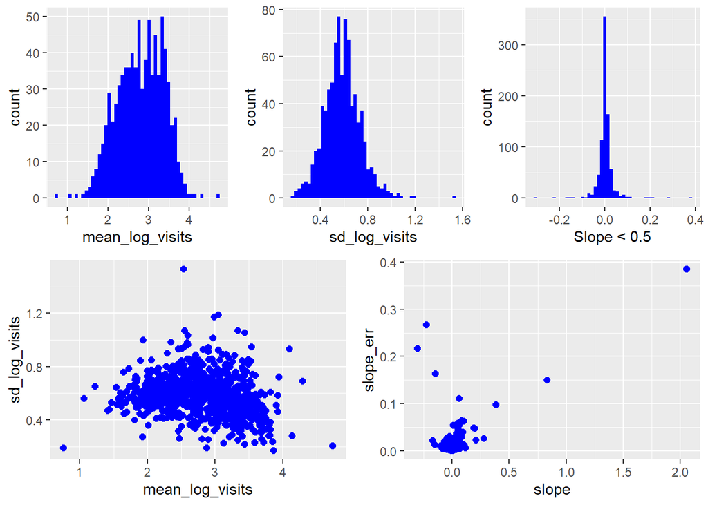

```r
p1 <- ts_params %>%
  ggplot(aes(mean_log_visits)) +
  geom_histogram(bins = 50, fill = "blue")

p2 <- ts_params %>%
  ggplot(aes(sd_log_visits)) +
  geom_histogram(bins = 50, fill = "blue")

p3 <- ts_params %>%
  filter(slope < 0.5) %>%
  ggplot(aes(slope)) +
  geom_histogram(bins = 50, fill = "blue") +
  labs(x = "Slope < 0.5")

p4 <- ts_params %>%
  ggplot((aes(mean_log_visits, sd_log_visits))) +
  geom_point(size = 2, color = "blue")

p5 <- ts_params %>%
  ggplot((aes(slope, slope_err))) +
  geom_point(size = 2, color = "blue")

layout <- matrix(c(1,1,2,2,3,3,4,4,4,5,5,5),2,6,byrow=TRUE)
multiplot(p1, p2, p3, p4, p5, layout=layout)
```

結果分析:

- 經由轉換出來的平均值和標準差的分佈相對較寬。但儘管分佈是相對對稱的，我不認為可以假設它們都是常態分佈的。
- 左下角 mean vs sd 的圖形可證實這兩個特徵之間存在關係，平均訪客數量越大平方差越小。
- Slope 分佈窄，右下角的 slope v.s slope error 圖顯示在較大的斜率誤差有異常值，且大多數斜率絕對值較高

```r
ts_params %>%
  filter(abs(slope) > 0.25) %>%
  select(air_store_id, air_genre_name, slope, slope_err) %>%
  mutate(slope = round(slope, 3),
         slope_err = round(slope_err, 3)) %>% ptable()
```

| air_store_id | air_genre_name | slope | slope_err |
| --- | --- | --- | --- |
| air_1c0b150f9e696a5f | Okonomiyaki/Monja/Teppanyaki | -0.305 | 0.217 |
| air_8110d68cc869b85e | Izakaya | 0.382 | 0.098 |
| air_900d755ebd2f7bbd | Italian/French | 2.055 | 0.385 |
| air_965b2e0cf4119003 | Izakaya | 0.277 | 0.027 |
| air_9c6787aa03a45586 | Cafe/Sweets | 0.832 | 0.150 |

# 6 預測方法 (Forecasting methods)

經過上面了解關於數據集及其特徵之後，開始把重點轉向時間序列預測方法。 將會選用時間序列分析中常見的兩種模型：

## 6.1 ARIMA模型

首先是ARIMA（Autoregressive Integrated Moving Average）模型， 這是一種相當流行的預測方法。它結合了自回歸（AR）、整合（I）和移動平均（MA）三個元素。ARIMA模型假設時間序列數據具有隨機性和時間相依性，通過過去觀測值的組合和殘差的加權平均來進行預測。ARIMA模型通常需要對時間序列進行平穩化處理，並選擇合適的模型參數。

- 自回歸 (auto-regressive) / p：使用過去 data 來計算未來的回歸模型，而參數 p 表示滯後的範圍
- 整合 (integrated) / d：這是一個差分參數，為我們提供減去時間序列的當前值和先前值的次數。 差分可以消除時間序列中的變化，因為它穩定了均值並消除了（季節性）趨勢。
- 移動平均 (moving average) / q：此參數提供了在模型回歸誤差中的先前誤差項的數量。

使用 auto.arima 為每個單獨的時間序列估計必要的 ARIMA 參數，且使用 ts 工具轉換， 再透過 forecast 套件的 tsclean function 添加一個清理和異常值移除步驟。

首先先用 *air_store_id (“air_ba937bf13d40fb24”)* 作為例子:

```r
air_id = "air_ba937bf13d40fb24"
```

為了測試我們的預測，我們將預測與我們最終要預測的相同時間範圍（4 月 23 日至 5 月 31 日）。 從 *test* 預測範圍的長度中提取這 39 天，並將其定義為預測長度。

```r
pred_len <- test %>%
  separate(id, c("air", "store_id", "date"), sep = "_") %>%
  distinct(date) %>%
  nrow()
```

選擇訓練樣本的最後 39 天來做預測。 再創建了一個包含所有 *visit_dates* 的數據集來為許多有間隙的時間序列做準備。

```r
max_date <- max(air_visits$visit_date)
split_date <- max_date - pred_len
all_visits <- tibble(visit_date = seq(min(air_visits$visit_date), max(air_visits$visit_date), 1))
```

提取特定 *air_store_id* 的時間序列，透過 log1p 轉換訪客數並加到所有 *visit_dates* 的數據集， 而這導致了一些 NA值，選擇用整體中位數來填滿。

```r
foo <- air_visits %>%
  filter(air_store_id == air_id)

visits <- foo %>%
  right_join(all_visits, by = "visit_date") %>%
  mutate(visitors = log1p(visitors)) %>%
  replace_na(list(visitors = median(log1p(foo$visitors)))) %>%
  rownames_to_column()
```

使用這個新的時間序列，將數據分成 *training sets* 和 *validation sets*。

```r
visits_train <- visits %>% filter(visit_date <= split_date)
visits_valid <- visits %>% filter(visit_date > split_date)
```

使用擬合的 ARIMA 模型，將預測我們的“預測長度”，其中包含信賴區間。

```r
arima.fit <- auto.arima(tsclean(ts(visits_train$visitors, frequency = 7)),
                        stepwise = FALSE, approximation = FALSE)
```

```r
arima_visits <- arima.fit %>% forecast(h = pred_len, level = c(50,95))
```

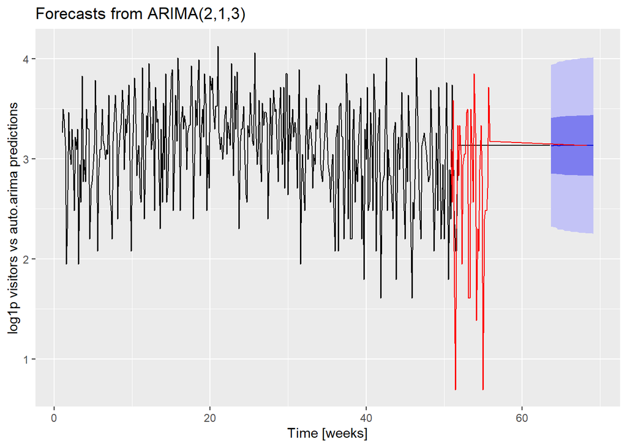

Fig. 31

```r
arima_visits %>%
  autoplot +
  geom_line(aes(as.integer(rowname)/7, visitors), data = visits_valid, color = "red") +
  labs(x = "Time [weeks]", y = "log1p visitors vs auto.arima predictions")
```

結果分析:

- 預測的前幾天非常吻合，但隨後預測無法捕捉更大的峰值。

```r
plot_auto_arima_air_id <- function(air_id){

  pred_len <- test %>%
    separate(id, c("air", "store_id", "date"), sep = "_") %>%
    distinct(date) %>%
    nrow()

  max_date <- max(air_visits$visit_date)
  split_date <- max_date - pred_len
  all_visits <- tibble(visit_date = seq(min(air_visits$visit_date), max(air_visits$visit_date), 1))

  foo <- air_visits %>%
    filter(air_store_id == air_id)

  visits <- foo %>%
    right_join(all_visits, by = "visit_date") %>%
    mutate(visitors = log1p(visitors)) %>%
    replace_na(list(visitors = median(log1p(foo$visitors)))) %>%
    rownames_to_column()

  visits_train <- visits %>% filter(visit_date <= split_date)
  visits_valid <- visits %>% filter(visit_date > split_date)

  arima.fit <- auto.arima(tsclean(ts(visits_train$visitors, frequency = 7)),
                          stepwise = FALSE, approximation = FALSE)

  arima_visits <- arima.fit %>% forecast(h = pred_len, level = c(50,95))

  arima_visits %>%
    autoplot +
    geom_line(aes(as.integer(rowname)/7, visitors), data = visits_valid, color = "red") +
    labs(x = "Time [weeks]", y = "log1p visitors vs forecast")
}
```

把這個過程及繪出來的圖變成一個函數，應用在一些時間序列，包括前面的兩個 *Slope* 異常值

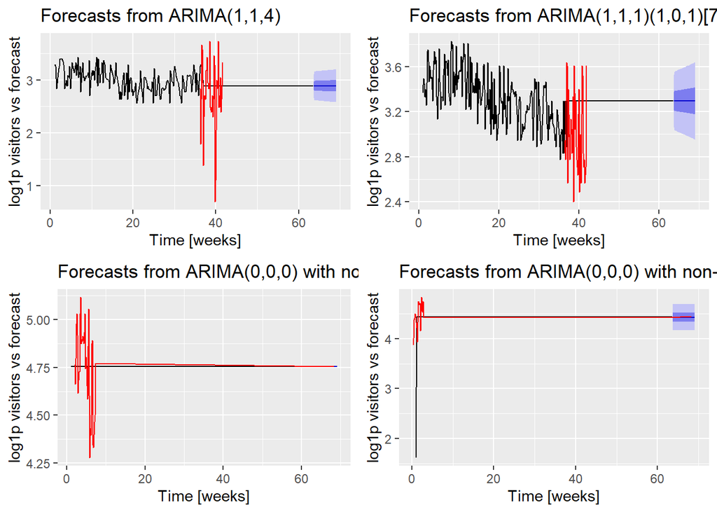

Fig. 31

```r
p1 <- plot_auto_arima_air_id("air_f3f9824b7d70c3cf")
p2 <- plot_auto_arima_air_id("air_8e4360a64dbd4c50")
p3 <- plot_auto_arima_air_id("air_1c0b150f9e696a5f")
p4 <- plot_auto_arima_air_id("air_900d755ebd2f7bbd")

layout <- matrix(c(1,2,3,4),2,2,byrow=TRUE)
multiplot(p1, p2, p3, p4, layout=layout)
```

結果分析:

- 上圖的兩個時間序列是合理完整的，但較長的間隔（和中間值填充）導致左上圖中的預測出現問題，失去了每週的周期性。 右上角則保留了這種週期性，前幾天的預測相對不錯，但隨後我們很快就低估了變化的幅度。
- 下面的圖包括在上面的時間序列參數中的兩個異常值，這邊可以看到真正出錯的例子。 如果這些特殊的時間序列在測試數據集中包含足夠大的訪問部分，則都可能會導致任何其他不錯的預測算法表現不佳。

以上總體來說，結果不是很好，但那是因為它是一個全自動預測（假設只有每週一次的周期），*auto.arima* 提供了第一個基準來和其他方法比較。

## 6.2 Holt-Winters模型

接著第二種方法來看 Holt-Winters模型，更傳統的時間序列過濾和預測都是用這種算法， 這是一種用於時間序列預測的指數平滑方法，也稱為三次指數平滑法。 它將時間序列的未來值建模為趨勢（Trend）、季節性（Seasonality）和水平（Level）的組合。 Holt-Winters模型能夠處理具有趨勢和季節性的數據，並且可以考慮季節性變化的長期和短期影響。 與ARIMA模型相比，Holt-Winters模型對季節性變化的建模更加直觀。

先在擬合和繪圖函數中定義了一個默認的季節性模型:

```r
plot_hw_air_id <- function(air_id){

  pred_len <- test %>%
    separate(id, c("air", "store_id", "date"), sep = "_") %>%
    distinct(date) %>%
    nrow()

  max_date <- max(air_visits$visit_date)
  split_date <- max_date - pred_len
  all_visits <- tibble(visit_date = seq(min(air_visits$visit_date), max(air_visits$visit_date), 1))

  foo <- air_visits %>%
    filter(air_store_id == air_id)

  visits <- foo %>%
    right_join(all_visits, by = "visit_date") %>%
    mutate(visitors = log1p(visitors)) %>%
    replace_na(list(visitors = median(log1p(foo$visitors)))) %>%
    rownames_to_column()

  visits_train <- visits %>% filter(visit_date <= split_date)
  visits_valid <- visits %>% filter(visit_date > split_date)

  hw.fit <- HoltWinters(tsclean(ts(visits_train$visitors, frequency = 7)))

  hw_visits <- predict(hw.fit, n.ahead = pred_len, prediction.interval = T, level = 0.95) %>%
    as.tibble() %>%
    bind_cols(visits_valid)

  visits_train %>%
    ggplot(aes(visit_date, visitors)) +
    geom_line() +
    geom_ribbon(data = hw_visits, aes(x = visit_date, ymin = lwr, ymax = upr), fill = "light blue") +
    geom_line(data = hw_visits, aes(visit_date, visitors), color = "red") +
    geom_line(data = hw_visits, aes(visit_date, fit), color = "blue") +
    geom_line(data = hw_visits, aes(visit_date, fit), color = "blue") +
    labs(x = "Time [weeks]", y = "log1p visitors vs predictions") +
    ggtitle("HoltWinters")
}
```

將此函數應用到範例時間序列:

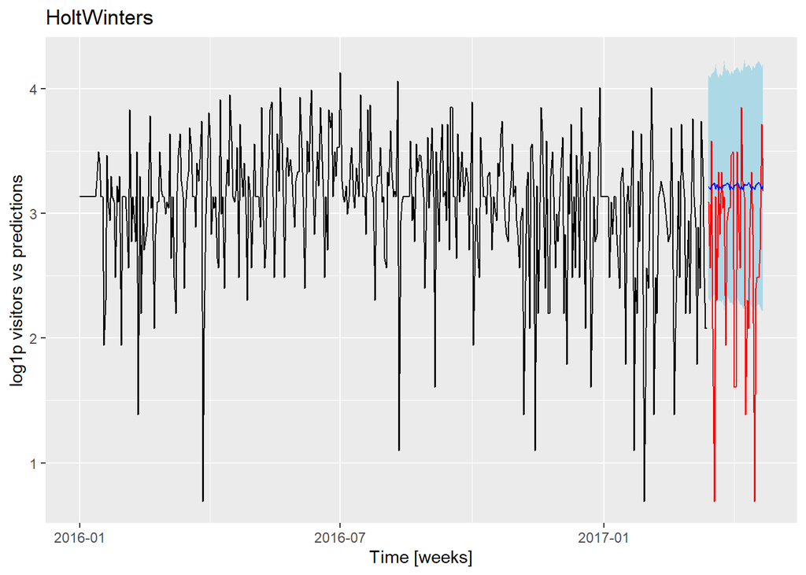

Fig. 37

```r
plot_hw_air_id("air_ba937bf13d40fb24")
```

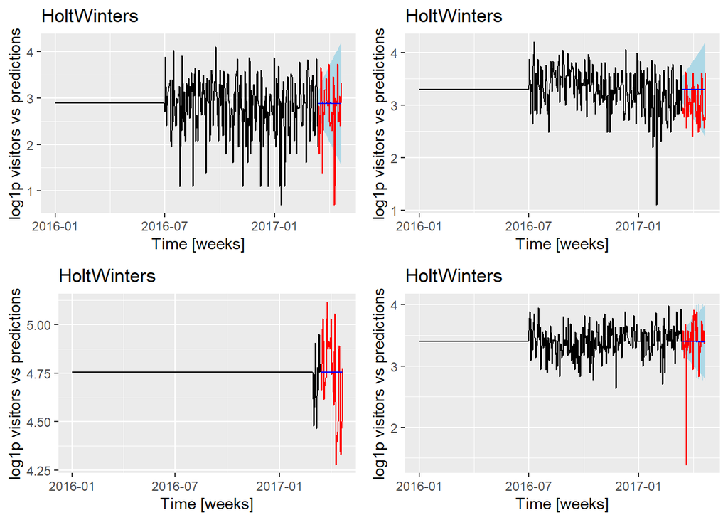

Fig. 38

```r
p1 <- plot_hw_air_id("air_f3f9824b7d70c3cf")
p2 <- plot_hw_air_id("air_8e4360a64dbd4c50")
p3 <- plot_hw_air_id("air_1c0b150f9e696a5f")
p4 <- plot_hw_air_id("air_820d1919cbecaa0a")

layout <- matrix(c(1,2,3,4),2,2,byrow=TRUE)
multiplot(p1, p2, p3, p4, layout=layout)
```

結果分析:

- 雖然這種算法在給定足夠數據的情況下表現相當好，但與 *auto.arima* 類似，它會針對丟失數據的特殊情況進行分解。
- 如果要有更好的表現可能要把缺失值丟掉而不是用中位數替換。

## 6.3 Prophet 模型

最後一種方法就是 Prophet ，這是一個由 Facebook 開發的時間序列預測工具。它是一種開源的軟體庫，用於預測和分析時間序列數據。 Prophet的目標是使時間序列預測變得更加簡單且易於使用，結合了統計模型和機器學習方法，可以自動處理常見的時間序列分析任務，例如處理缺失數據、處理季節性效應和假日效應等。

將以 ARIMA 的部分作為基礎，再次為上面相同時期（即 3 月 14 日之前/之後）創立訓練集和驗證集。 與 ARIMA 模型的唯一區別是：

- 不需要替換 NA 值，因為 Prophet 知道如何處理。
- 需要一個包含兩列的數據框：ds 用於日期，y 用於時間序列變量。

```r
air_id = "air_ba937bf13d40fb24"

pred_len <- test %>%
  separate(id, c("air", "store_id", "date"), sep = "_") %>%
  distinct(date) %>%
  nrow()

max_date <- max(air_visits$visit_date)
split_date <- max_date - pred_len
all_visits <- tibble(visit_date = seq(min(air_visits$visit_date), max(air_visits$visit_date), 1))

foo <- air_visits %>%
  filter(air_store_id == air_id)

visits <- foo %>%
  right_join(all_visits, by = "visit_date") %>%
  mutate(visitors = log1p(visitors)) %>%
  rownames_to_column() %>%
  select(y = visitors,
         ds = visit_date)

visits_train <- visits %>% filter(ds <= split_date)
visits_valid <- visits %>% filter(ds > split_date)
```

擬合先知模型並進行預測，而需要注意的是:

- 參數 *changepoint.prior.scale* 可以調整趨勢的靈活性。 增加這個參數使擬合更加靈活，但也增加了預測的不確定性並讓它更容易產生過度擬合的麻煩， 除非使用 *changepoints* 參數手動指定。
- 參數 *yearly.seasonality* 必須明確啟用或是禁用並允許 prophet 注意到大規模週期。

```r
proph <- prophet(visits_train, changepoint.prior.scale=0.5, yearly.seasonality=FALSE, daily.seasonality = FALSE)
future <- make_future_dataframe(proph, periods = pred_len)
fcast <- predict(proph, future)
```

標準的 Prophet 預測圖:

黑點為觀察到的數據，擬合模型加上預測繪製為藍線，而在淺藍色中，我們看到相應的不確定性。

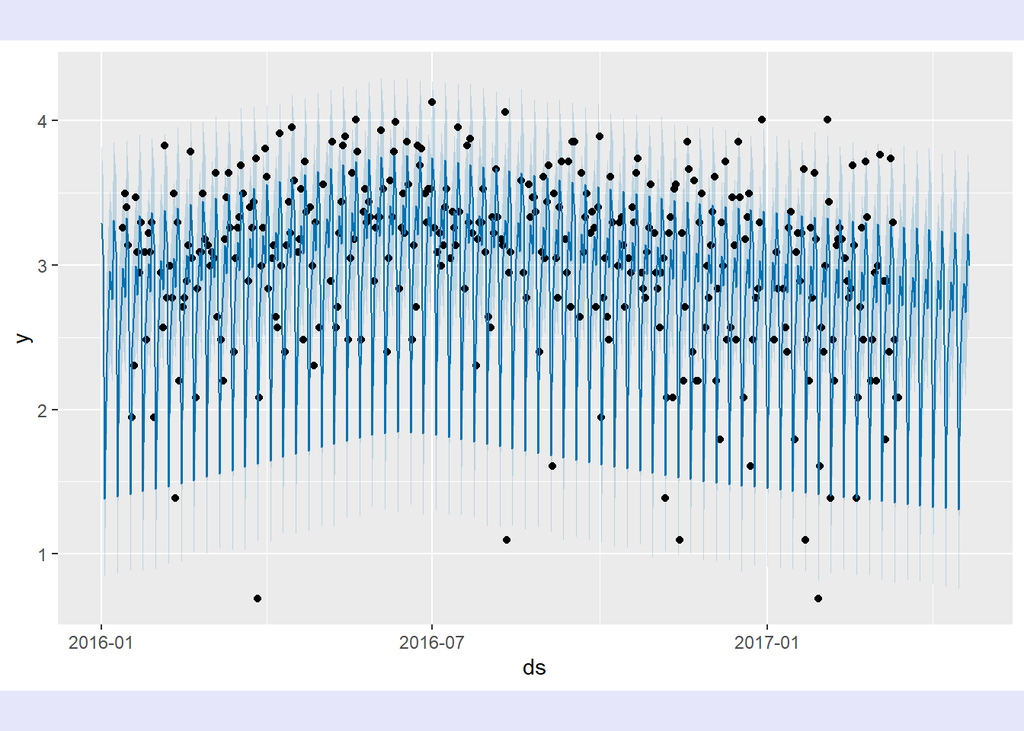

Fig. 32

```r
plot(proph, fcast)
```

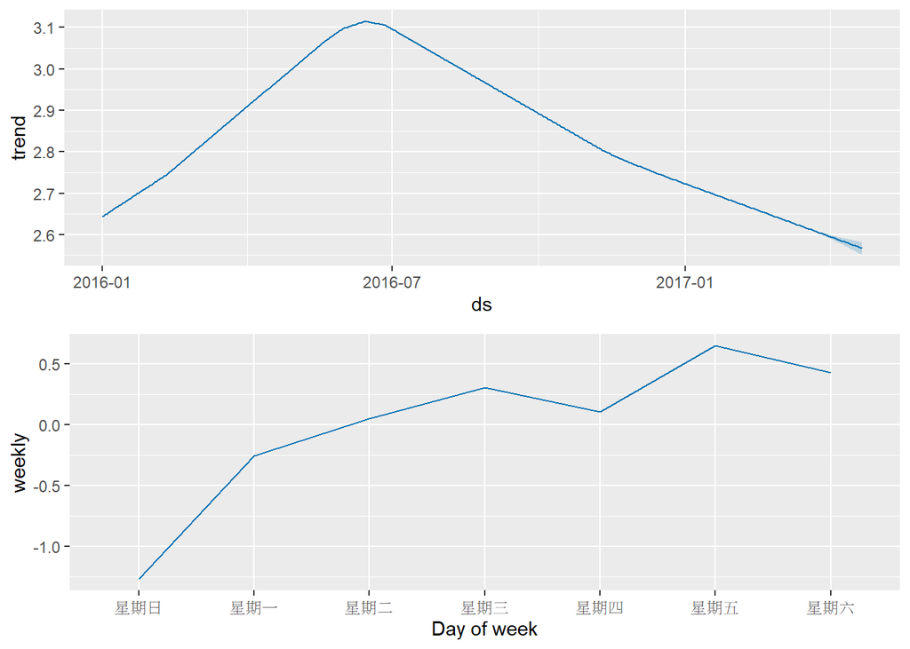

Fig. 33

```r
prophet_plot_components(proph, fcast)
```

圖表分析:

所以：這是一個好的開始！

接下來使用值得信賴的 ggplot2 來讓我們更好的控制繪圖參數：

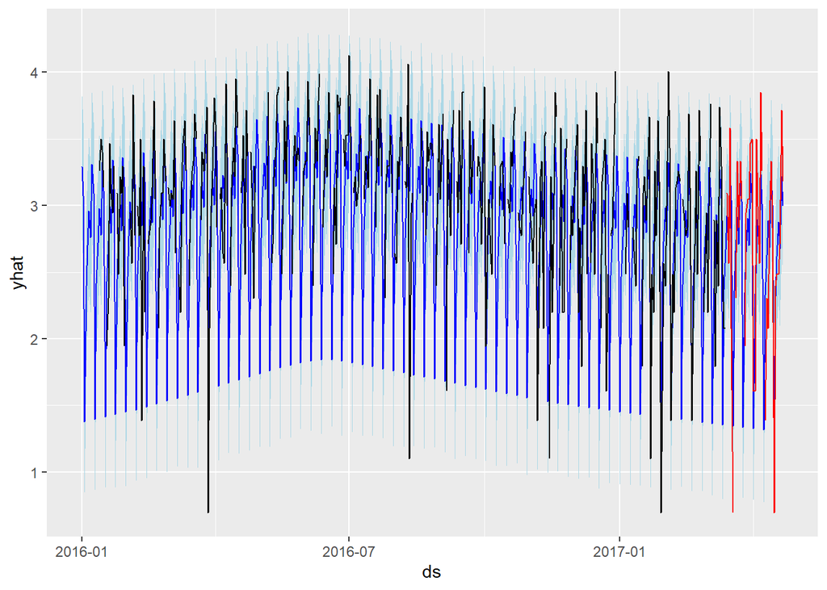

Fig. 34

```r
fcast %>%
  as.tibble() %>%
  mutate(ds = date(ds)) %>%
  ggplot(aes(ds, yhat)) +
  geom_ribbon(aes(x = ds, ymin = yhat_lower, ymax = yhat_upper), fill = "light blue") +
  geom_line(colour = "blue") +
  geom_line(data = visits_train, aes(ds, y), colour = "black") +
  geom_line(data = visits_valid, aes(ds, y), colour = "red")
```

看起來還不錯。 再次用黑色繪製訓練集訪客數，以紅色繪製驗證集，以藍色和淺藍色繪製預測加上不確定性。

```r
plot_prophet_air_id <- function(air_id){

  pred_len <- test %>%
    separate(id, c("air", "store_id", "date"), sep = "_") %>%
    distinct(date) %>%
    nrow()

  max_date <- max(air_visits$visit_date)
  split_date <- max_date - pred_len
  all_visits <- tibble(visit_date = seq(min(air_visits$visit_date), max(air_visits$visit_date), 1))

  foo <- air_visits %>%
    filter(air_store_id == air_id)

  visits <- foo %>%
    right_join(all_visits, by = "visit_date") %>%
    mutate(visitors = log1p(visitors)) %>%
    rownames_to_column() %>%
    select(y = visitors,
          ds = visit_date)

  visits_train <- visits %>% filter(ds <= split_date)
  visits_valid <- visits %>% filter(ds > split_date)

  proph <- prophet(visits_train, changepoint.prior.scale=0.5,
                   yearly.seasonality=FALSE, daily.seasonality = FALSE)
  future <- make_future_dataframe(proph, periods = pred_len)
  fcast <- predict(proph, future)

  p <- fcast %>%
    as.tibble() %>%
    mutate(ds = date(ds)) %>%
    ggplot(aes(ds, yhat)) +
    geom_ribbon(aes(x = ds, ymin = yhat_lower, ymax = yhat_upper), fill = "light blue") +
    geom_line(colour = "blue") +
    geom_line(data = visits_train, aes(ds, y), colour = "black") +
    geom_line(data = visits_valid, aes(ds, y), colour = "red") +
    labs(title = str_c("Prophet for ", air_id))

  return(p)
}
```

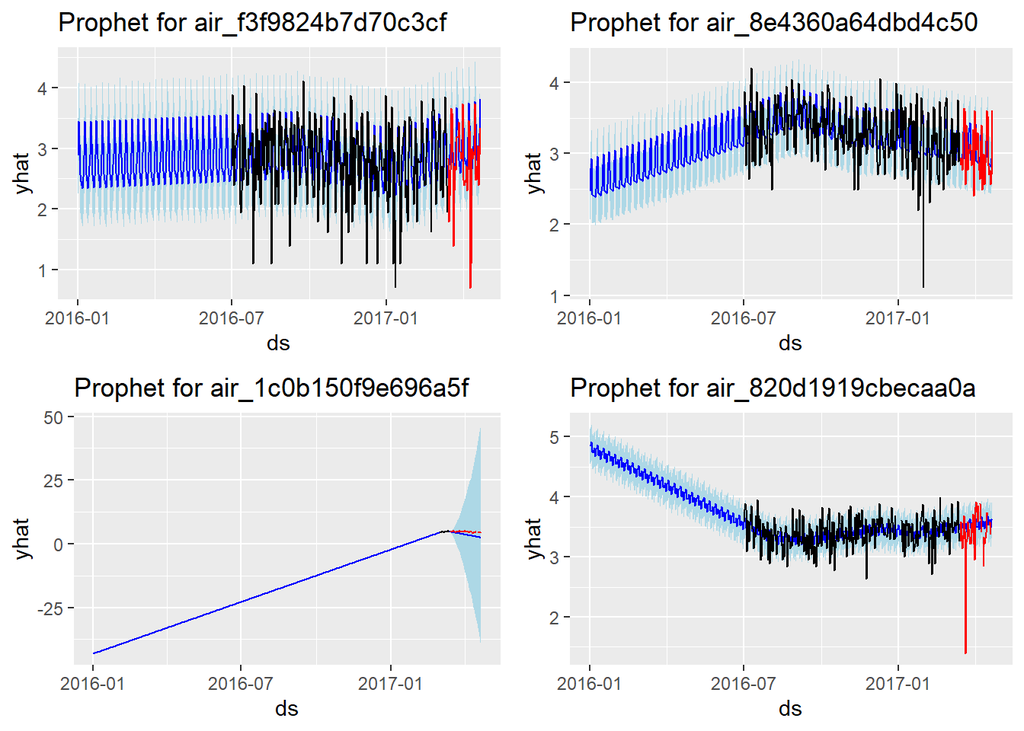

Fig. 35

```r
p1 <- plot_prophet_air_id("air_f3f9824b7d70c3cf")
p2 <- plot_prophet_air_id("air_8e4360a64dbd4c50")
p3 <- plot_prophet_air_id("air_1c0b150f9e696a5f")
p4 <- plot_prophet_air_id("air_820d1919cbecaa0a")

layout <- matrix(c(1,2,3,4),2,2,byrow=TRUE)
multiplot(p1, p2, p3, p4, layout=layout)
```

接著修改函數來看預測 2016 年黃金周時假期是否會產生影響。 只需要根據Prophet’s liking 對 *Holiday_data* 重新命名就可將它包含在預測功能中。 在中間步驟中截斷 2016 年 5 月 31 日的 air_visits data:

```r
plot_prophet_air_id_holiday <- function(air_id, use_hday){

  air_visits_cut <- air_visits %>%
    filter(visit_date <= ymd("20160531"))

  hday <- holidays %>%
    filter(holiday_flg == TRUE) %>%
    mutate(holiday = "holiday") %>%
    select(ds = date, holiday)

  pred_len <- test %>%
    separate(id, c("air", "store_id", "date"), sep = "_") %>%
    distinct(date) %>%
    nrow()

  max_date <- max(air_visits_cut$visit_date)
  split_date <- max_date - pred_len
  all_visits <- tibble(visit_date = seq(min(air_visits_cut$visit_date), max(air_visits_cut$visit_date), 1))

  foo <- air_visits_cut %>%
    filter(air_store_id == air_id)

  visits <- foo %>%
    right_join(all_visits, by = "visit_date") %>%
    mutate(visitors = log1p(visitors)) %>%
    rownames_to_column() %>%
    select(y = visitors,
          ds = visit_date)

  visits_train <- visits %>% filter(ds <= split_date)
  visits_valid <- visits %>% filter(ds > split_date)

  if (use_hday == TRUE){
    proph <- prophet(visits_train,
                     changepoint.prior.scale=0.5,
                     yearly.seasonality=FALSE,
                     daily.seasonality=FALSE,
                     holidays = hday)
    ptitle = "Prophet (w/ holidays) for "
  } else {
     proph <- prophet(visits_train,
                     changepoint.prior.scale=0.5,
                     yearly.seasonality=FALSE,
                     daily.seasonality = FALSE)
    ptitle = "Prophet for "
  }

  future <- make_future_dataframe(proph, periods = pred_len)
  fcast <- predict(proph, future)

  p <- fcast %>%
    as.tibble() %>%
    mutate(ds = date(ds)) %>%
    ggplot(aes(ds, yhat)) +
    geom_ribbon(aes(x = ds, ymin = yhat_lower, ymax = yhat_upper), fill = "light blue") +
    geom_line(colour = "blue") +
    geom_line(data = visits_train, aes(ds, y), colour = "black") +
    geom_line(data = visits_valid, aes(ds, y), colour = "red") +
    labs(title = str_c(ptitle, air_id))

  return(p)
}
```

採用一個表現佳的時間序列並比較 有 / 沒有 假期的預測：

[figure not shown]

Fig. 36

```r
p1 <- plot_prophet_air_id_holiday("air_5c817ef28f236bdf", TRUE)
p2 <- plot_prophet_air_id_holiday("air_5c817ef28f236bdf", FALSE)

layout <- matrix(c(1,2),2,1,byrow=TRUE)
multiplot(p1, p2, layout=layout)
```

結果分析:

- 當包括假期時，在擬合黃金周訪客方面有細微的改進。
- 如果訓練集中包含更多假期，該組件的表現可能會更好。

# 7 問題回答

## 7.1 從哪裡得到計畫想法

由於剛好家裡親人從事餐飲業，近年來經濟不景氣導致餐飲業競爭越來越激烈，為了提高競爭力，我便希望能夠利用自己所學的知識來優化營銷策略，藉此來提高運營效率，並且降低成本和風險。

## 7.2 用了哪些套件或函數

- visualization:ggplot2,scales,grid,gridExtra,RColorBrewer,corrplot,ggrepel,ggridges,ggExtra,ggforce,viridis
- data manipulation:dplyr,readr,data.table,tibble,tidyr,stringr,forcats,lubridate,timeDate,tseries,forecast,prophet,timetk
- Maps / geospatial:geosphere,leaflet,leaflet.extras,maps

## 7.3 最難的部分是什麼

- 最常見的是knit成html時的問題。有時在rmd的時候可以執行，但卻在knit的時候出現error。而另一個問題是不管用什麼辦法都會出現「套件或命名空間載入失敗」的訊息，也就是目前使用的R版本和相關套件的版本無法兼容，最好只好卸載R和RStudio才能徹底解決。
- 我希望不同的分析方式可以找到最適合的圖表來呈現，因此花費許多心思在圖表的構想上，而在製作的過程中，我覺得最困難的部分是將搜集到的資料，整理成畫圖所需要的格式，且在資料視覺化時，也需要考量到圖形的視覺舒適度，須將長寬調整成適合的比例，才可以方便數據的判讀。
- 第一次運用標籤分頁、使網頁排版乾淨整齊，在美化版面時，有遇到Rmarkdown與CSS結合的問題，在這部分也花費較多時間上網查詢解決方法。

## 7.4 這堂課收穫

這份專題的最後，特別想感謝鍾老師。在學習上這學期的金融大數據課程以及上學期的衍生性金融市場，老師寫的PresTree在學習上都給了我很大的幫助，使用上來說十分清楚且實用，在PresTree架構下所呈現的教材清晰明瞭。R對我而言是幾乎是從零開始，寫出這份專題雖然碰到不少困難，也感到挫折，但很感謝老師在這門課上讓我學到相當扎實的R語言操作，以及了解更多不同套件及函數的應用，雖然每次都需要花許多時間，但每次做完都很有成就感，感謝鍾老師這學期的教導!